# 气泡图

庄亮亮

2020/11/10

# 气泡图

气泡图是一种多变量图表，是散点图的变体，也可以认为是 散点图和百分比区域图的组合。气泡图最基本的用法是使用三个值来确定每个数据序列，和散点图一样。气泡图通过气泡的位置及面积大小，可分析数据之间的相关性。

本文可以看作是《R语言数据可视化之美》的学习笔记。前两部分可见（跳转）：

- 趋势显示的二维散点图
- 分布显示的二维散点图

该书对气泡图的绘制并不是非常详细，小编将内容进行了大量拓展。下面的例子将一步步带你完成气泡图的绘制。本文内容丰富，希望大家都能学到自己想要的内容。

## 本文框架

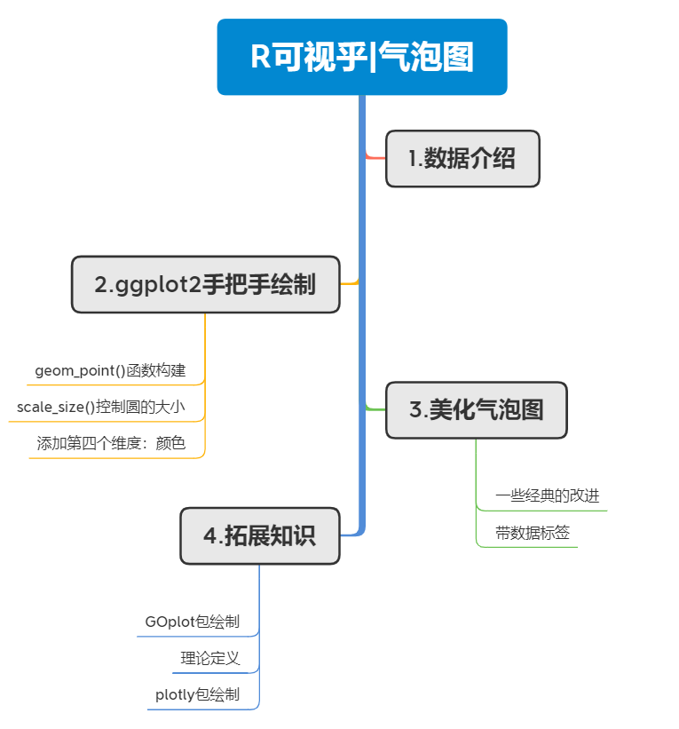

## 数据介绍

数据集来源gapminder包中，包含了1704行和6个变量。其中6个变量含义分别为：

- country 国家142个水平
- continent 大陆5个水平
- year 1952年-2007年（间隔为5年）
- lifeExp 出生预期寿命，以年计数
- pop 人口数
- gdpPercap 人均国内生产总值(扣除通货膨胀因素后的美元)

由于数据过多，我们感兴趣的是年份为2007年的数据，所以使用dplyr包进行数据处理，具体数据处理案例可见我写的另一篇推送：[[R数据科学]tidyverse数据清洗案例详解](https://mp.weixin.qq.com/s/ozH-TsltnLwp51i3aDNpSQ)。数据缩略版如下：

```r
library(ggplot2)
library(dplyr)
library(gapminder)
data <- gapminder %>% filter(year=="2007") %>% dplyr::select(-year)
```

## 手把手绘制

### geom_point()函数构建

气泡图是添加了第三维度的散点图：附加数值变量的值通过点的大小表示。(来源:[data-to-viz](https://www.data-to-viz.com/graph/bubble.html))。 使用ggplot2，可以通过`geom_point()`函数构建气泡图。`aes()`设定至少三个变量:x、y和size。其实就是散点图绘制的升级版吧，`aes()`中多了一个参数。

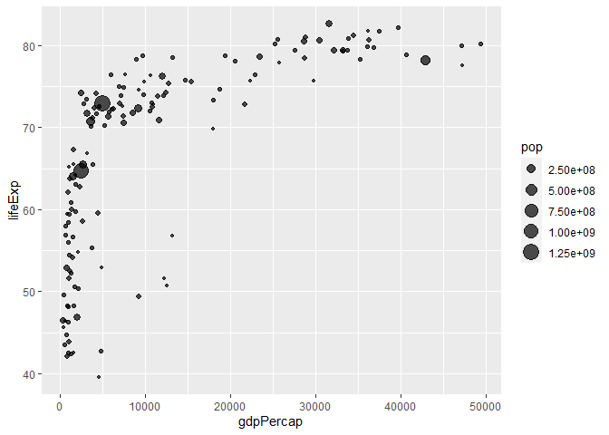

```r
ggplot(data, aes(x=gdpPercap, y=lifeExp, size = pop)) +
    geom_point(alpha=0.7)
```

上图展示了世界各国的预期寿命(y)与人均国内生产总值(x)之间的关系。每个国家的人口用圆的大小表示。但是这个图不是非常美观，而且圆的大小并不是很直观，大家都差不多大。接下来对圆的大小进行设定。

### scale_size()控制圆的大小

scale_size()允许使用range参数设置最小和最大的圆的大小，用`name`改变图例名称(`scale_size(range = c(0.1, 24), name="Population (M)")`)。

- 图中可以看到，有些圆圈重叠了。k可将点的透明度进行调整（`geom_point(alpha=0.5)`）
- 为了避免在图表顶部出现大的圆圈，可以将数据集进行排序(`arrange(desc(pop))`)，代码如下。

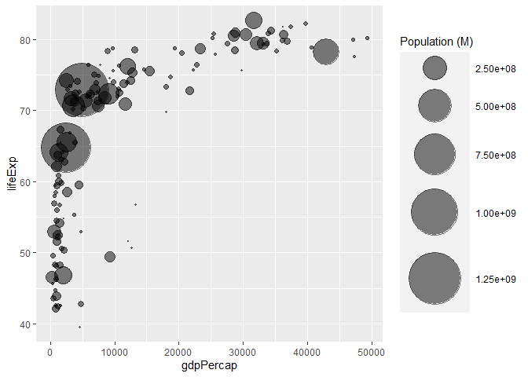

```r
data %>%
  arrange(desc(pop)) %>%
  mutate(country = factor(country)) %>%
  ggplot(aes(x=gdpPercap, y=lifeExp, size = pop)) +
    geom_point(alpha=0.5) +
    scale_size(range = c(.1, 24), name="Population (M)")
```

现在图可读性有所提高，但如果数据集中还有一个变量想加入图中该怎么办呢？

### 添加第四个维度：颜色

这里可以用每个国家的洲来控制圆圈的颜色（`aes(x=gdpPercap, y=lifeExp, size=pop, color=continent)`）:

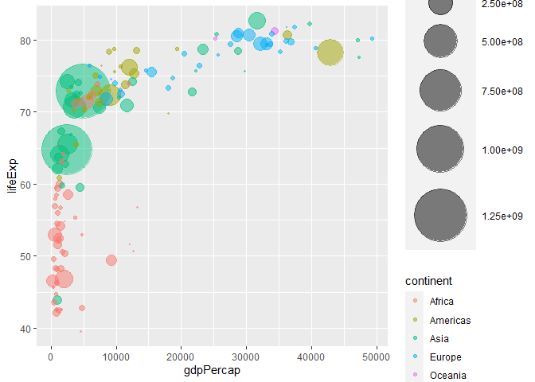

```r
data %>%
  arrange(desc(pop)) %>%
  mutate(country = factor(country, country)) %>%
  ggplot(aes(x=gdpPercap, y=lifeExp, size=pop, color=continent)) +
    geom_point(alpha=0.5) +
    scale_size(range = c(.1, 24), name="Population (M)")
```

该图基本可以满足我们日常生活的气泡图的可视化了。相信大家通过前面的详细的介绍，应该可以自行绘制，只要换个数据，懂得各个代码的含义即可。后面是图表美化的过程，参考[thr R Graph Gallery: Bubble plot with ggplot2](https://www.r-graph-gallery.com/320-the-basis-of-bubble-plot.html)。

## 美化气泡图

### 一些经典的改进

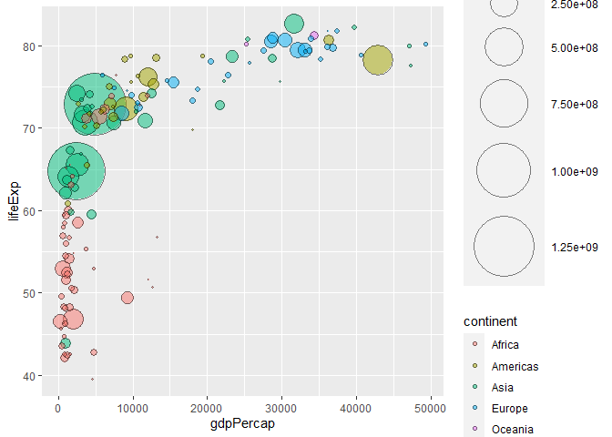

```r
# Libraries
library(hrbrthemes)
library(viridis)

# Most basic bubble plot
data %>%
  arrange(desc(pop)) %>%
  mutate(country = factor(country, country)) %>%
  ggplot(aes(x=gdpPercap, y=lifeExp, size=pop, fill=continent)) +
    geom_point(alpha=0.5, shape=21, color="black") +
    scale_size(range = c(.1, 24), name="Population (M)") #+
```

```r
    #scale_fill_viridis(discrete=TRUE, guide=FALSE, option="A") +
    #theme_ipsum() +
    #theme(legend.position="bottom") +
    #ylab("Life Expectancy") +
    #xlab("欢迎关注：庄闪闪的成长手册 \nq  Gdp per Capita") +
    #theme(legend.position = "none")
```

### 带数据标签

这里使用ggrepel包中的(`geom_text_repel()`)，可以给每个点自动加入标签，我这里是加入了各个国家名字，其他可以根据你实际需求进行设置。

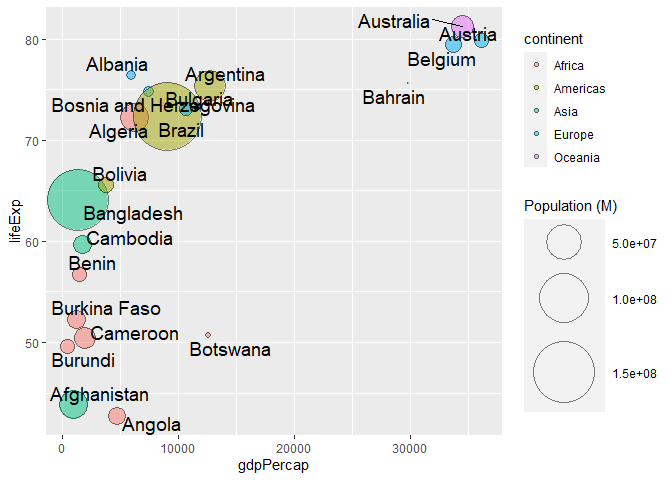

```r
library(ggrepel)
library(viridis)
library(hrbrthemes)
data1 = data %>%
  mutate(country = factor(country)) %>% head(20)
attach(data1)
  ggplot(data1,aes(x=gdpPercap, y=lifeExp, size=pop, fill=continent)) +
    geom_point(alpha=0.5, shape=21, color="black") +
    scale_size(range = c(.1, 24), name="Population (M)") +
    geom_text_repel(label = country,size=5)#+
```

```r
    #scale_fill_viridis(discrete=TRUE, guide=FALSE, option="A") +
    #theme_ipsum() +
    #theme(legend.position="bottom") #+
    #ylab("Life Expectancy") +
    #xlab("欢迎关注：庄闪闪的成长手册 \nq  Gdp per Capita") +
    #theme(legend.position = "none")
```

如果不喜欢圆形的气泡图，可以将代码中的`shape=21`进行更改，正方形是`shape=22`，得到的图如下：

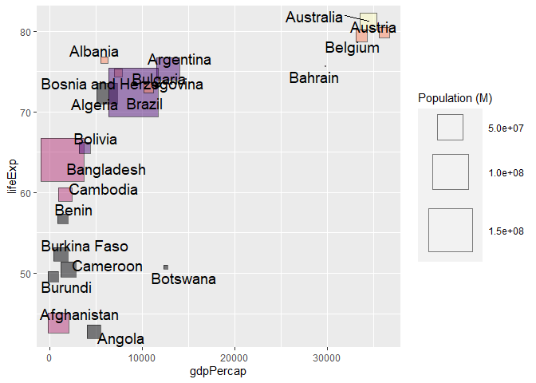

```r
library(ggrepel)
data1 = data %>%
  mutate(country = factor(country)) %>% head(20)
attach(data1)
  ggplot(data1,aes(x=gdpPercap, y=lifeExp, size=pop, fill=continent)) +
    geom_point(alpha=0.5, shape=22, color="black") +
    scale_size(range = c(.1, 24), name="Population (M)") +
    geom_text_repel(label = country,size=5)+
    scale_fill_viridis(discrete=TRUE, guide=FALSE, option="A") #+
```

```r
    #theme_ipsum() +
    #theme(legend.position="bottom") +
    #ylab("Life Expectancy") +
    #xlab("欢迎关注：庄闪闪的成长手册 \nq  Gdp per Capita") +
    #theme(legend.position = "none")
```

## 拓展知识

其他扩展可自行学（小编做推送的时候已经学过啦，但是篇幅有限，就没继续整理下去了）

- [GOplot包](https://wencke.github.io/)提供了直接做气泡图的方法，函数是：GOBubble。

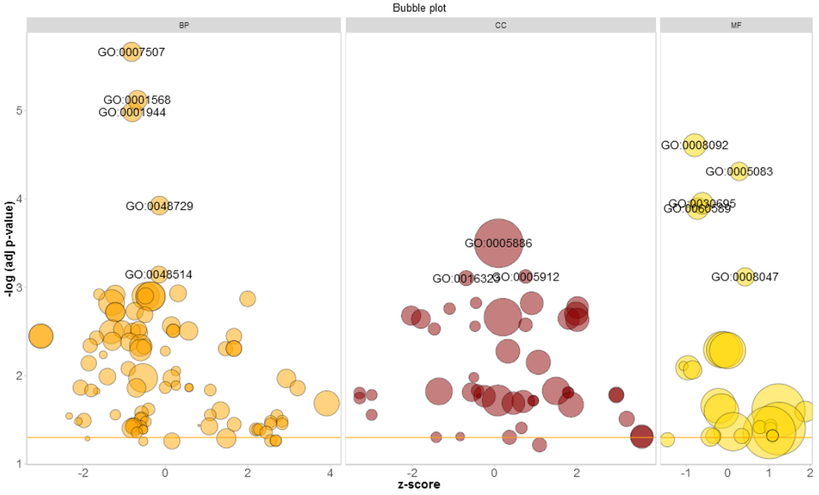

- [BUBBLE PLOT理论定义](https://www.data-to-viz.com/graph/bubble.html)

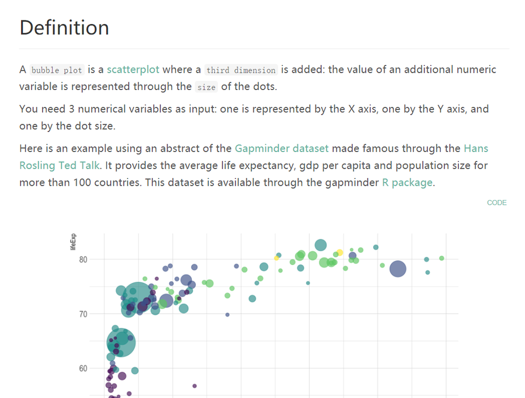

- [plotly包](https://plotly.com/r/bubble-charts/)绘制可以互动的气泡图

[figure not shown]

## R语言数可视化书内代码

```r
library(ggplot2)
library(RColorBrewer)
library(ggrepel)
attach(mtcars)
head(mtcars)
```

```
##                    mpg cyl disp  hp drat    wt  qsec vs am gear carb
## Mazda RX4         21.0   6  160 110 3.90 2.620 16.46  0  1    4    4
## Mazda RX4 Wag     21.0   6  160 110 3.90 2.875 17.02  0  1    4    4
## Datsun 710        22.8   4  108  93 3.85 2.320 18.61  1  1    4    1
## Hornet 4 Drive    21.4   6  258 110 3.08 3.215 19.44  1  0    3    1
## Hornet Sportabout 18.7   8  360 175 3.15 3.440 17.02  0  0    3    2
## Valiant           18.1   6  225 105 2.76 3.460 20.22  1  0    3    1
```

### 带数据标签的气泡图

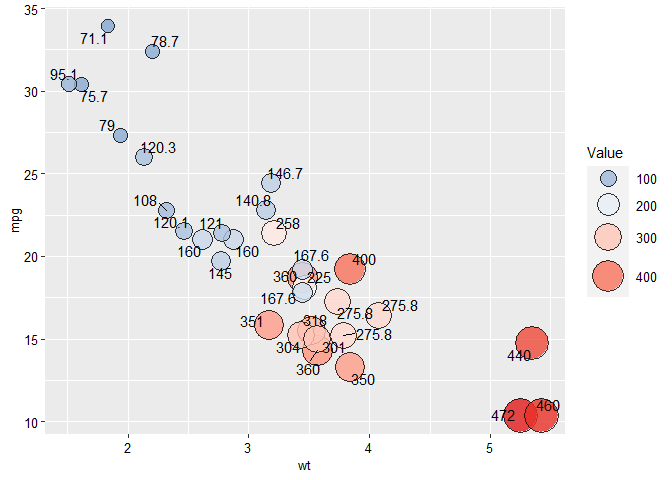

```r
 ggplot(data=mtcars, aes(x=wt,y=mpg))+
   geom_point(aes(size=disp,fill=disp),shape=21,colour="black",alpha=0.8)+
   scale_fill_gradient2(low="#377EB8",high="#E41A1C",midpoint = mean(mtcars$disp))+
   geom_text_repel(label = disp )+
   scale_size_area(max_size=12)+
   guides(size = guide_legend((title="Value")),
          fill = guide_legend((title="Value")))+
   theme(
     legend.text=element_text(size=10,face="plain",color="black"),
     axis.title=element_text(size=10,face="plain",color="black"),
     axis.text = element_text(size=10,face="plain",color="black"),
     legend.position = "right"
   )
```

### 方块状的气泡图

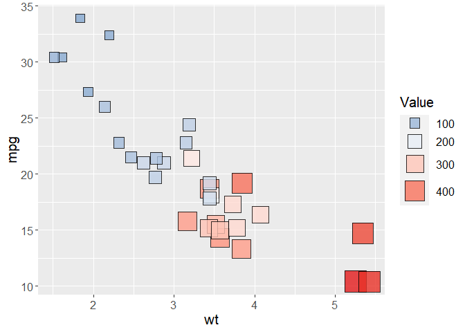

```r
ggplot(mtcars, aes(wt,mpg))+
  geom_point(aes(size=disp,fill=disp),shape=22,colour="black",alpha=0.8)+
  scale_fill_gradient2(low=brewer.pal(7,"Set1")[2],high=brewer.pal(7,"Set1")[1],
                       midpoint = mean(mtcars$disp))+
  scale_size_area(max_size=12)+
  guides(fill = guide_legend((title="Value")),
         size =  guide_legend((title="Value")))+
  theme(
    text=element_text(size=15,color="black"),
    plot.title=element_text(size=15,family="myfont",face="bold.italic",color="black")#,
    #legend.position=c(0.9,0.05)
  )
```